# Rangsummentest von Wilcoxon in R

Curdin Derungs

Winter 2022

## Ziel

Theoretische Grundlagen und Anwendungsfälle des Wilcoxon Rangsummentest (RST) wurden im Rahmen der Probevorlesung bereits erläutert. In diesem Dokument wird der Wilcoxon RST für einfache und gepaarte Stichproben anhand von R-Code berechnet.

## Einfachstichprobenfall

### Hypothese

Wir möchten untersuchen, ob die Student:innen Statistik mögen oder nicht. Dazu testen wir die Nullhypothese *Den Student:innen ist Statistik egal*.

Für den Wilcoxon RST bedeutet dies:

- $H_{0}: \sum(+)Rng = \sum(-)Rng$ (ein positiver Rang bedeutet eine Präferenz > 5)
- $H_{A}: \sum(+)Rng > \sum(-)Rng$ (einseitiger Test)

### Daten

Die Daten ‘erstellen’ wir selbst:

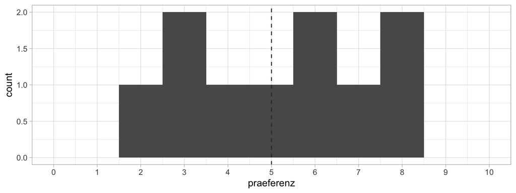

```r
dat <- data.frame(id = 1:10, praeferenz = c(4,5,8,3,6,8,6,3,2,7))

ggplot(dat)+
  geom_histogram(aes(x=praeferenz), bins = 11)+
  geom_vline(xintercept = 5, color="grey20", linetype=2)+
  scale_x_continuous(limits = c(0,10), n.breaks = 10)+
  theme_light()
```

### ‘Manueller’ Test

Wie bereits im Unterricht anhand des Einstichprobenfalles besprochen, wählen wir folgendes Vorgehen:

- Berechnen der Differenzen
- Rangieren der Differenzen
- Summieren der Differenzen

In einem ersten Schritt werden die Differenzen berechnet und daraus die Ränge hergeleitet. Eine positive Differenz bedeutet, die Präferenz grösser als 5 ist.

```r
## Differenzen zum Erwartungswert = 5 berechnen
dat$diff <- dat$praeferenz - 5

## Differenzen von 0 müssen aus der Berechnung herausgenommen werden (gibt es in diesem Beispiel nicht)
dat$diff[dat$diff == 0] <- NA

## Rangieren der absoluten Differenzen
dat$rank <- rank(abs(dat$diff), na.last = 'keep')

## Tabelle auspielen
kable(dat, caption="Differenzen und Ränge")
```

Differenzen und Ränge

| id | praeferenz | diff | rank |
| --- | --- | --- | --- |
| 1 | 4 | -1 | 2 |
| 2 | 5 | NA | NA |
| 3 | 8 | 3 | 8 |
| 4 | 3 | -2 | 5 |
| 5 | 6 | 1 | 2 |
| 6 | 8 | 3 | 8 |
| 7 | 6 | 1 | 2 |
| 8 | 3 | -2 | 5 |
| 9 | 2 | -3 | 8 |
| 10 | 7 | 2 | 5 |

Die Ränge werden dann separat für die positiven und negativen Abweichungen vom Erwartungswert summiert:

```r
## Erwartete Ranksumme
V_exp <- sum(dat$rank, na.rm = T) / 2

## Positive Ranksumme
V_pos <- sum(dat$rank[dat$diff > 0], na.rm = T)

## Netative Ranksumme
V_neg <- sum(dat$rank[dat$diff < 0], na.rm = T)

V <- max(c(V_pos,V_neg))
```

Folgende Rangsummen resultieren aus den Beispieldaten:

- $V_{exp} =$ 22.5
- $V_{pos} =$ 25
- $V_{neg} =$ 20
- $V = max(V_{neg};V_{pos}) = V_{pos} =$ 25

Die Teststatistik sieht folgendermassen aus:  
$z = \frac{V - V_{exp}}{\delta_{v}}$

Wie bereits in der Vorlesung erwähnt, werden wir nicht näher auf den Standardfehler von $V$, d.h. $\delta_{v}$, eingehen. Dieser ist etwas kompliziert herzuleiten.

### R-Funktion

Und endlich lernen Sie, wie man den Wilcoxon RST für den Einfachstichprobenfall in R berechnet. Dazu benützen wir die R-Funktion `wilcox.test`.

Wir können der Funktion die Präferenz, zusammen mit einem `mu`-Parameter übergeben. Wir verwenden den Erwartungswert der Nullhypothese und setzen `mu = 5`. Die Alternativhypothese möchten wir einseitig testen, nämlich `alternative = 'greater'`. Wir sind daran interessiert zu zeigen, dass die Präferenzen der Student:innen in positive Richtung von der Nullhypothese abweichen.

Der Test ergibt dann folgenden Output:

```r
## Wilcoxon RST berechnen
wilcox.test(dat$praeferenz, mu=5, alternative = 'greater')
```

```
##
##  Wilcoxon signed rank test with continuity correction
##
## data:  dat$praeferenz
## V = 25, p-value = 0.4054
## alternative hypothesis: true location is greater than 5
```

### Interpretation

Beobachtung:

- Die beobachtete Rangsumme $V = 25$ im R-Output entspricht der ‘manuell’ berechneten Rangsumme.
- Die beobachtete Rangsumme ist unter Annahme von $H_{0}$ ziemlich wahrscheinlich. Der P-Wert liegt bei 0.4 und ist damit deutlich grösser als ein Signifikanzniveau von 0.05.

Die $H_0$, dass Student:innen Statistik egal ist, kann nicht verworfen werden.

## Gepaarte Stichproben

### Hypothese

Wir möchten nun testen, ob sich die Präferenzen, welche anfangs Probelektion erhoben wurden, durch die Lektion verändert haben. Die Nullhypothese lautet, dass *die Präferenzen am Anfang und am Ende der Probelektion unverändert sind*.

Für den Wilcoxon RST bedeutet dies:

- $H_{0}: \sum(+)Rng = \sum(-)Rng$ (ein positiver Rang bedeutet eine höhere Präferenz Ende Probelektion)
- $H_{A}: \sum(+)Rng > \sum(-)Rng$ (einseitiger Test)

### Daten

Wir fügen den Präferenzen, welche zu Beginn erhoben wurden, noch eine zweite Serie Präferenzen hinzu. Für jede Student:in haben wir nun zwei Messungen, eine zu Beginn des Unterrichts und eine am Ende. Es handelt sich also um gepaarte Stichproben.

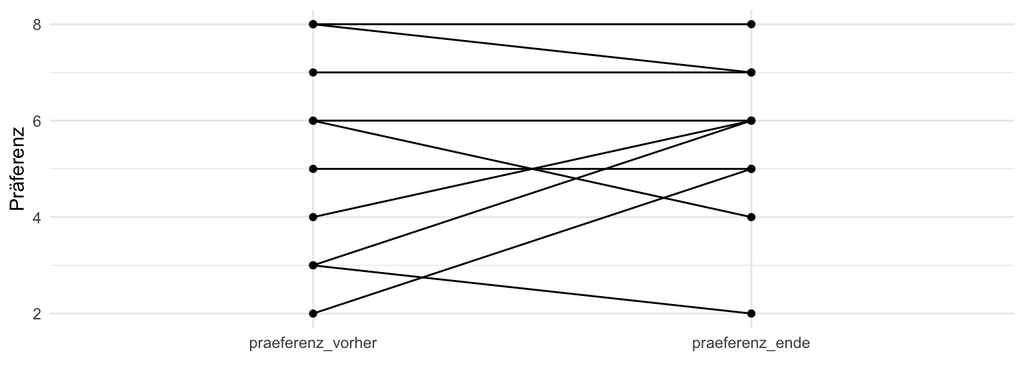

```r
## Daten lesen
dat_paired <- data.frame(id = dat$id, praeferenz_vorher = dat$praeferenz)

dat_paired$praeferenz_ende <- c(6,5,8,6,4,7,6,2,5,7)

dat_long <- melt(dat_paired, id.vars=c("id"))
ggplot(dat_long) +
  geom_point(aes(x = variable, y = value)) +
  geom_line(aes(x  = variable, y = value, group = id))+
  ylab("Präferenz")+
  xlab("")+
  theme_minimal()
```

### ‘Manueller’ Test

Wir wählen das gleiche Vorgehen wie bei dem Einstichprobenfall:

- Berechnen der Differenzen
- Rangieren der Differenzen
- Summieren der Differenzen

In einem ersten Schritt werden die Differenzen berechnet und daraus die Ränge hergeleitet. Die Differenzen werden nun zwischen den Präferenzen anfangs und am Ende der Lektion berechnet. Ein positiver Wert bedeutet, dass sich die Präferenz erhöht hat.

```r
## Differenzen zum Erwartungswert = 5 berechnen
dat_paired$diff <-  dat_paired$praeferenz_ende - dat_paired$praeferenz_vorher

## Differenzen von 0 müssen aus der Berechnung herausgenommen werden (gibt es in diesem Beispiel nicht)
dat_paired$diff[dat_paired$diff == 0] <- NA

## Rangieren der absoluten Differenzen
dat_paired$rank <- rank(abs(dat_paired$diff), na.last = 'keep')

## Tabelle auspielen
kable(dat_paired, caption="Differenzen und Ränge")
```

Differenzen und Ränge

| id | praeferenz_vorher | praeferenz_ende | diff | rank |
| --- | --- | --- | --- | --- |
| 1 | 4 | 6 | 2 | 3.5 |
| 2 | 5 | 5 | NA | NA |
| 3 | 8 | 8 | NA | NA |
| 4 | 3 | 6 | 3 | 5.5 |
| 5 | 6 | 4 | -2 | 3.5 |
| 6 | 8 | 7 | -1 | 1.5 |
| 7 | 6 | 6 | NA | NA |
| 8 | 3 | 2 | -1 | 1.5 |
| 9 | 2 | 5 | 3 | 5.5 |
| 10 | 7 | 7 | NA | NA |

Die Ränge werden dann separat für die positiven und negativen Abweichungen vom Erwartungswert summiert:

```r
## Erwartete Ranksumme
V_exp <- sum(dat_paired$rank, na.rm = T) / 2

## Positive Ranksumme
V_pos <- sum(dat_paired$rank[dat_paired$diff > 0], na.rm = T)

## Netative Ranksumme
V_neg <- sum(dat_paired$rank[dat_paired$diff < 0], na.rm = T)

V <- max(c(V_pos,V_neg))
```

Folgende Rangsummen resultieren aus den Beispieldaten:

- $V_{exp} =$ 10.5
- $V_{pos} =$ 14.5
- $V_{neg} =$ 6.5
- $V = max(V_{neg};V_{pos}) = V_{pos} =$ 14.5

Die Teststatistik sieht folgendermassen aus:  
$z = \frac{V - V_{exp}}{\delta_{v}}$

### R-Funktion

Die `wilcox.test` Funktion wird ähnlich wie im Einstichprobenfall verwendet. Nun übergeben wir der Funktion zwei Messreihen. ACHTUNG: Wenn wir `alternative = 'greater'` definieren, dann müssen wir als erste Messreihe diejenige angeben, welche wir als grösser testen möchten! Zudem müssen wir `paired = TRUE` definieren, damit ein paarweiser Test ausgeführt wird.

Der Test ergibt dann folgenden Output:

```r
## Wilcoxon RST berechnen
wilcox.test(dat_paired$praeferenz_ende,dat_paired$praeferenz_vorher, paired = TRUE, alternative = 'greater')
```

```
##
##  Wilcoxon signed rank test with continuity correction
##
## data:  dat_paired$praeferenz_ende and dat_paired$praeferenz_vorher
## V = 14.5, p-value = 0.2297
## alternative hypothesis: true location shift is greater than 0
```

### Interpretation

Beobachtung:

- Die beobachtete Ranksumme $V = 14.5$ im R-Output entspricht der ‘manuell’ berechneten Ranksumme.
- Die beobachtete Ranksumme ist unter Annahme von $H_{0}$ wiederum recht wahrscheinlich. Der P-Wert liegt bei 0.22 und ist damit deutlich grösser als ein Signifikanzniveau von 0.05.